# 64748e92-ab07-4228-8d8f-24863d019c8f

## Шаг 1. Откройте файл с данными и изучите общую информацию

```python
import pandas as pd
import numpy as np
import matplotlib.pyplot as plt
import math
from IPython.display import display
from scipy import stats as st
```

```python
games = pd.read_csv('/datasets/games.csv')
```

```python
games.info()
```

```
<class 'pandas.core.frame.DataFrame'>
RangeIndex: 16715 entries, 0 to 16714
Data columns (total 11 columns):
Name               16713 non-null object
Platform           16715 non-null object
Year_of_Release    16446 non-null float64
Genre              16713 non-null object
NA_sales           16715 non-null float64
EU_sales           16715 non-null float64
JP_sales           16715 non-null float64
Other_sales        16715 non-null float64
Critic_Score       8137 non-null float64
User_Score         10014 non-null object
Rating             9949 non-null object
dtypes: float64(6), object(5)
memory usage: 1.4+ MB
```

## Вывод

Дататасет состоит из 11 столбцов и 16715 строк. Следующие столбцы содержат пропуски:

- *Name* — название игры — 2 пропуска;
- *Year_of_Release* — год выпуска — 269 пропусков;
- *Critic_Score* — оценка критиков — 8578 пропусков;
- *User_Score* — оценка пользователей — 6701 пропуск;
- *Rating* — рейтинг от организации ESRB — 6766 пропусков.

## Шаг 2. Подготовьте данные

Выгрузим датасет в файл Excel методом `to_excel()`.

```python
# games.to_excel('games.xlsx')
```

Заполним пропуски в столбце *Critic_Score*. Для этого воспользуемся средством автоматизации AutoIt. Напишем скрипт, который копирует название игры, платформу и год выпуска из таблицы Excel, переключается на окно браузера и вставляет значения в поисковик, допечатывая фразу "metacritic score" (сайт-агрегатор Metacritic используется в качестве основного источника оценок). На странице результатов поиска скрипт через Ctrl+f ищет первый попавшийся символ % (как правило, это и есть оценка критиков), копирует значение перед ним, переключается в окно Excel и вставляет в соответствующий столбец.

Очевидные недостатки: скорость работы — для обработки 8578 строк потребовались две ночи); ненадёжность — браузер подвисает, требуется перезапуск скрипта; неточность — может путать результат для серий игр или не выдавать ничего — для малоизвестных тайтлов. Тем не менее способ прост и обладает потенциалом для усовершенствования.

Листинг программы с комментариями и результат обработки приведены по ссылкам.

https://yadi.sk/d/O50RGeucFtKMQQ

https://yadi.sk/d/lm20jsZyoAnRUQ

Аналогично заполним пропуски в столбце *Year_of_Release*. Допечатываем в поисковик фразу "год выпуска", ищем на странице результатов "год выпуска:", копируем значение после двоеточия.

Загрузим обработанный датасет из файла Excel и изучим общую информацию.

```python
games2 = pd.read_excel('https://s178vla.storage.yandex.net/rdisk/8309e24126d4d5862c3afc9ab843a21090debd926f3610a39b287571ed7b4e97/5f6bff9d/HDBV4UnNRqi12hm1V6JtQ2b2XjPJ0jK9L2AK6Tjb-CVZ_hjHLkoyh36mmA6Xo2o09OaRfvNELvc2ksHq0hP3Xw==?uid=0&filename=games.xlsx&disposition=attachment&hash=bodlPOwkEXaMXK2xZ9oCJ9w1yVnv/gUU/xBZHc8V4yG/KKBNdSDxoqGUhnaWcB/Zq/J6bpmRyOJonT3VoXnDag%3D%3D&limit=0&content_type=application%2Fvnd.openxmlformats-officedocument.spreadsheetml.sheet&owner_uid=1119693063&fsize=1199713&hid=2c1b191f8659f92c77434f38698947fe&media_type=document&tknv=v2&rtoken=dQvuyh9aWIPH&force_default=no&ycrid=na-1affdfb1dd452f1351aa6f0b4d514473-downloader16e&ts=5b005ad196140&s=38b21d334958f56702938bd37ae1f8f42a77720edcce4f2b0d40623f7d1b14de&pb=U2FsdGVkX1_iwq19eWnYPI4mBgW0_hO8hHjAbS9yZ6W7qUcx7d1rhOYVY5xacw3TyGdpKlGI3B8IGq6iDwMF6nGEQBB8dRQNOaGF57ZfMHE')
```

```python
games2.info()
```

```
<class 'pandas.core.frame.DataFrame'>
RangeIndex: 16715 entries, 0 to 16714
Data columns (total 11 columns):
Name               16713 non-null object
Platform           16715 non-null object
Year_of_Release    16643 non-null float64
Genre              16713 non-null object
NA_sales           16715 non-null float64
EU_sales           16715 non-null float64
JP_sales           16715 non-null float64
Other_sales        16715 non-null float64
Critic_Score       15441 non-null float64
User_Score         10014 non-null object
Rating             9949 non-null object
dtypes: float64(6), object(5)
memory usage: 1.4+ MB
```

Заменим названия столбцов (приведём к нижнему регистру) методом `str.lower()`.

```python
games2.columns = games2.columns.str.lower()
games2.columns
```

```
Index(['name', 'platform', 'year_of_release', 'genre', 'na_sales', 'eu_sales',
       'jp_sales', 'other_sales', 'critic_score', 'user_score', 'rating'],
      dtype='object')
```

Выведем на экран строки с пропусками в столбце *name*.

```python
games2[games2['name'].isnull()]
```

|  | name | platform | year_of_release | genre | na_sales | eu_sales | jp_sales | other_sales | critic_score | user_score | rating |
| --- | --- | --- | --- | --- | --- | --- | --- | --- | --- | --- | --- |
| 659 | NaN | GEN | 1993.0 | NaN | 1.78 | 0.53 | 0.00 | 0.08 | 51.0 | NaN | NaN |
| 14244 | NaN | GEN | 1993.0 | NaN | 0.00 | 0.00 | 0.03 | 0.00 | 51.0 | NaN | NaN |

Строки неинформативны, удалим их. В столбце *year_of_release* 72 пропуска, что составляет 0,43% всех данных. Удалим их тоже.

```python
games2 = games2.dropna(subset=['name', 'year_of_release'])
```

Пропуски в столбцах *critic_score*, *rating* оставим без изменения, поскольку удаление соответствующих строк может негативно сказаться на результатах исследования.

Заменим тип данных столбца *year_of_release* на целочисленный методом `astype()`.

```python
games2['year_of_release'] = games2['year_of_release'].astype('int')
```

Аббревиатура *tbd* (To Be Determined — будет определено или To Be Decided — будет решено) в столбцах с оценками пользователей означает, что пользовательские оценки отсутствуют или их недостаточно, чтобы выставить оценку игре. Для работы со столбцом *user_score* необходимо избавиться от значения *tbd* и заменить тип данных на вещественный. Заменим значения *tbd* в столбце *user_score* на значение из столбца *critic_score*, поделённое на 10.

```python
games2.loc[games2['user_score'] == 'tbd', 'user_score'] = games2.loc[games2['user_score'] == 'tbd', 'critic_score'] / 10
```

Заменим тип данных столбца *user_score* на вещественный методом `astype()`.

```python
games2['user_score'] = games2['user_score'].astype('float')
```

Заменим пропуски в столбце *user_score* значениями стобца *critic_score*, поделёнными на десять.

```python
games2.loc[games2['user_score'].isnull(), 'user_score'] = games2.loc[games2['user_score'].isnull(), 'critic_score'] / 10
```

Построим гистограммы оценок.

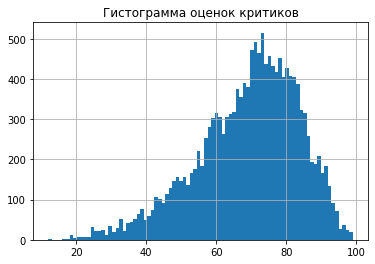

```python
games2['critic_score'].hist(bins=len(games2['critic_score'].unique()))
plt.title('Гистограмма оценок критиков');
```

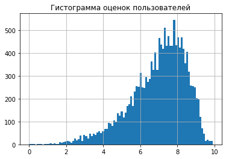

```python
games2['user_score'].hist(bins=len(games2['user_score'].unique()))
plt.title('Гистограмма оценок пользователей');
```

Посчитаем суммарные продажи во всех регионах и запишем их в отдельный столбец *total_sales*.

```python
games2['total_sales'] = games2['na_sales'] + games2['eu_sales'] + games2['jp_sales'] + games2['other_sales']
```

## Вывод

Для заполнения пропусков в столбцах можно копировать значения из открытых источников средством автоматизации AutoIt.

Возможные причины пропусков — ошибки названий для серий игр или для малоизвестность тайтлов.

Пропуски в столбцах *critic_score*, *rating* оставим без изменения, поскольку удаление соответствующих строк может негативно сказаться на результатах исследования.

Аббревиатура tbd (To Be Determined — будет определено или To Be Decided — будет решено) в столбцах с оценками пользователей означает, что пользовательские оценки отсутствуют или их недостаточно, чтобы выставить оценку игре.

## Шаг 3. Проведите исследовательский анализ данных

Посмотрим, сколько игр выпускалось в разные годы. Для этого построим гистограмму количества игр по годам выпуска с количеством корзин, равным количеству лет наблюдения.

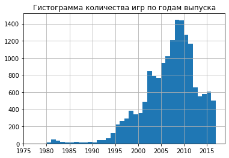

```python
games2['year_of_release'].hist(bins=len(games2['year_of_release'].unique()))
plt.title('Гистограмма количества игр по годам выпуска');
```

Посмотрим, как менялись продажи по платформам. Для этого создадим сводную таблицу `platform_total_sales`, сгруппировав по платформам и годам выпуска и просуммировав продажи.

```python
platform_total_sales = games2.pivot_table(index='platform', columns='year_of_release', values='total_sales', aggfunc='sum')
# platform_total_sales
```

Выберем платформы с наибольшими суммарными продажами, отсортируем по убыванию и выведем на экран первые 5 штук. Сохраним её в переменную `top5_popular_platforms`.

[output not shown]

[output cut: 162 more lines]

[output not shown]

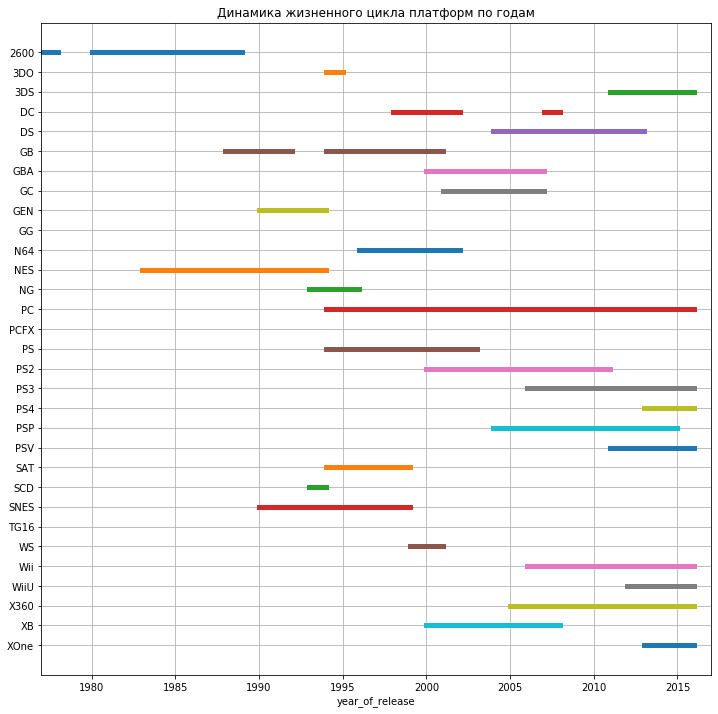

```python
plt.figure(figsize=(12, 12))
j = 32
plt.title('Динамика жизненного цикла платформ по годам')
for i in platform_total_sales.index:
    (
        platform_total_sales.mask(platform_total_sales > 0, 1).loc[i, range(1977, 2017)] *j
    ).plot(x='year_of_release', xlim=(1977, 2017), linewidth=5)
    j -= 1
plt.yticks(range(32, 1, -1), platform_total_sales.index)
plt.grid(True)
```

```python
top5_popular_platforms = platform_total_sales.sum(axis=1).sort_values(ascending=False).head()
top5_popular_platforms
```

```
platform
PS2     1253.21
X360     969.86
PS3      939.51
Wii      905.89
DS       805.29
dtype: float64
```

Посмотрим, как менялось количество платформ по годам.

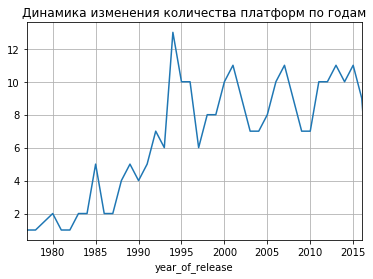

```python
plt.title('Динамика изменения количества платформ по годам')
platform_total_sales.notnull().sum().plot(x='year_of_release', xlim=(1977, 2016), grid=True);
```

Оценим жизненный цикл платформ. Для этого преобразуем сводную таблицу методом `notnull()` (если в году были продажи, тогда True, иначе False), просуммируем, отсортируем по убыванию и выведем на экран первые 10 штук.

```python
platform_total_sales.notnull().sum(axis=1).sort_values(ascending=False).head(10)
```

```
platform
PC      26
2600    16
PS3     14
DS      14
Wii     14
PS2     14
GB      13
X360    12
NES     12
XB      12
dtype: int64
```

Найдём средний жизненный цикл платформы.

```python
platform_total_sales.notnull().sum(axis=1).mean()
```

```
8.516129032258064
```

```python
# platform_total_sales.loc[:, range(2009, 2017)]
```

[output not shown]

В цикле для каждой платформы с наибольшими суммарными продажами построим график динамики суммарных продаж по годам и выведем их на одном графике.

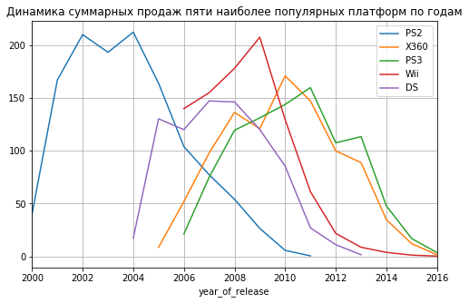

```python
plt.figure(figsize=(8, 5))
plt.title('Динамика суммарных продаж пяти наиболее популярных платформ по годам')
for i in top5_popular_platforms.index:
    platform_total_sales.loc[i, range(2000, 2017)].plot(x='year_of_release', xlim=(2000, 2016), label = i)
plt.legend()
plt.grid(True)
```

**Вывод:** платформы с наибольшими суммарными продажами — мёртвые платформы. Средний жизненный цикл платформы — 8.5 лет.

Выберем платформы с наибольшими суммарными продажами за 2016 год, отсортируем по убыванию и выведем на экран первые 5 штук. Сохраним её в переменную `top5_actual_popular_platforms`.

```python
top5_actual_popular_platforms = platform_total_sales.loc[:, 2016].sort_values(ascending=False).head()
top5_actual_popular_platforms
```

```
platform
PS4     69.25
XOne    26.15
3DS     15.14
PC       5.29
WiiU     4.60
Name: 2016, dtype: float64
```

В цикле для каждой платформы с наибольшими суммарными продажами за 2016 год построим график динамики суммарных продаж по годам и выведем их на одном графике.

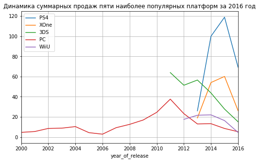

```python
plt.figure(figsize=(8, 5))
plt.title('Динамика суммарных продаж пяти наиболее популярных платформ за 2016 год')
for i in top5_actual_popular_platforms.index:
    platform_total_sales.loc[i, range(2000, 2017)].plot(x='year_of_release', xlim=(2000, 2016), label = i)
plt.legend()
plt.grid(True)
```

**Вывод:** самые прибыльные платформы на 2017 год — *PS4* и *Xbox One*. Продажи игр на *3DS* и *WiiU* падают. *PC* — самая стабильная платформа.

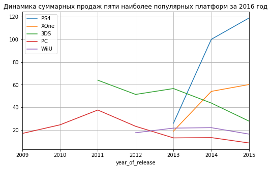

```python
plt.figure(figsize=(8, 5))
plt.title('Динамика суммарных продаж пяти наиболее популярных платформ за 2016 год')
for i in top5_actual_popular_platforms.index:
    platform_total_sales.loc[i, range(2009, 2016)].plot(x='year_of_release', xlim=(2009, 2015), label = i)
plt.legend()
plt.grid(True)
```

Изменим датасет в соответствие с актуальным периодом с 2009 по 2016 год.

```python
platform_total_sales = platform_total_sales.loc[:, range(2009, 2017)]
```

```python
games2 =games2.query('2009 <= year_of_release <= 2016')
```

Построим графики «ящик с усами» по глобальным продажам игр в разбивке по пяти наиболее популярным платформам. Для этого применим в цикле метод `boxplot()` к продажам в каждой платформе, отобранной методом `query()`.

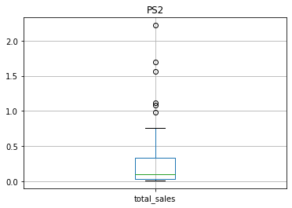

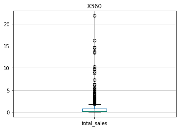

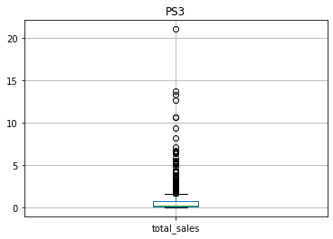

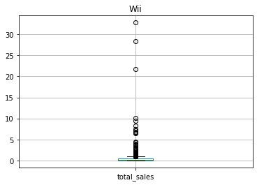

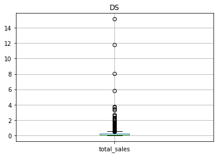

```python
for i in top5_popular_platforms.index:
    plt.figure()
    plt.title(i)
    games2.query('platform == @i').boxplot(column=['total_sales']);
```

Аналогично построим графики «ящик с усами» по по пяти актуальным платформам с наибольшими суммарными продажами за 2016 год.

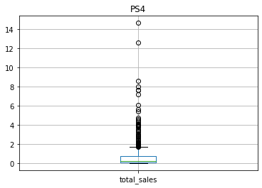

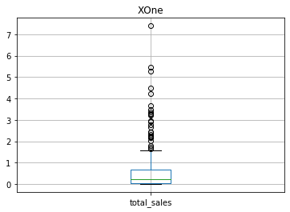

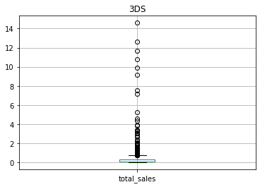

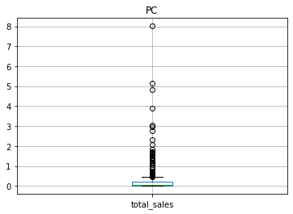

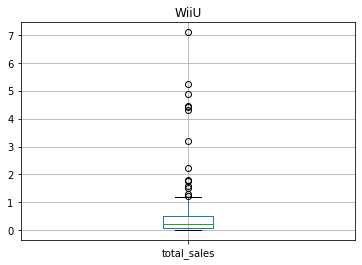

```python
for i in top5_actual_popular_platforms.index:
    plt.figure()
    plt.title(i)
    games2.query('platform == @i').boxplot(column=['total_sales']);
```

**Вывод:** рынок игр для всех платформ неоднороден. Есть очевидные хиты продаж и множество проходных игр.

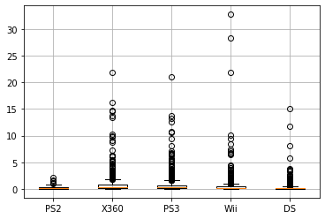

```python
top5_popular_platforms_boxplot = []
for i in top5_popular_platforms.index:
    top5_popular_platforms_boxplot.append(games2.query('platform == @i')['total_sales'])
plt.figure()
plt.boxplot(top5_popular_platforms_boxplot)
plt.xticks(range(1, 6), top5_popular_platforms.index)
plt.grid(True)
plt.show()
```

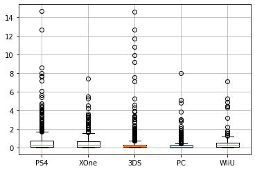

```python
top5_actual_popular_platforms_boxplot = []
for i in top5_actual_popular_platforms.index:
    top5_actual_popular_platforms_boxplot.append(games2.query('platform == @i')['total_sales'])
plt.figure()
plt.boxplot(top5_actual_popular_platforms_boxplot)
plt.xticks(range(1, 6), top5_actual_popular_platforms.index)
plt.grid(True)
plt.show()
```

Посмотрим, как влияют на продажи отзывы пользователей и критиков внутри платформы *PS2*. Для этого построим диаграмму рассеяния методом `pd.plotting.scatter_matrix(df)` для параметров *total_sales* и *critic_score*, отобрав их для *PS2* методом `query()` и исключив нулевые продажи.

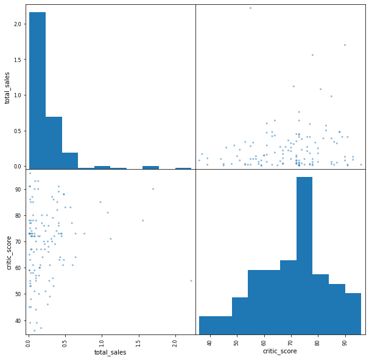

```python
pd.plotting.scatter_matrix(games2.query(
    'platform == "PS2" and total_sales != 0'
)[['total_sales', 'critic_score']], figsize=(10, 10));
```

Аналогично для параметров *total_sales* и *user_score*.

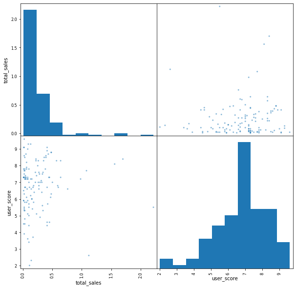

```python
pd.plotting.scatter_matrix(games2.query(
    'platform == "PS2" and total_sales != 0'
)[['total_sales', 'user_score']], figsize=(10, 10));
```

В цикле для каждой платформы с наибольшими суммарными продажами посчитаем корреляцию между отзывами и продажами методом `corr()`, исключив нулевые продажи.

```python
for i in top5_popular_platforms.index:
    display(i, games2.query(
        'platform == @i and total_sales != 0'
    )['total_sales'].corr(games2.query('platform == @i')['critic_score']))
```

```
'PS2'
```

```
0.14629228519349116
```

```
'X360'
```

```
0.317608411528962
```

```
'PS3'
```

```
0.3356918783661153
```

```
'Wii'
```

```
0.1595253892101686
```

```
'DS'
```

```
0.17716525911680575
```

В цикле для каждой платформы с наибольшими суммарными продажами за 2016 год посчитаем корреляцию между отзывами и продажами методом `corr()`, исключив нулевые продажи.

```python
for i in top5_actual_popular_platforms.index:
    display(i, games2.query(
        'platform == @i and total_sales != 0'
    )['total_sales'].corr(games2.query('platform == @i')['critic_score']))
```

```
'PS4'
```

```
0.325422646843615
```

```
'XOne'
```

```
0.3582242328610963
```

```
'3DS'
```

```
0.250320184841578
```

```
'PC'
```

```
0.2624727022168031
```

```
'WiiU'
```

```
0.32899581853970983
```

Аналогично для отзывов пользователей.

```python
for i in top5_popular_platforms.index:
    display(i, games2.query(
        'platform == @i and total_sales != 0'
    )['total_sales'].corr(games2.query('platform == @i')['user_score']))
```

```
'PS2'
```

```
0.04962239951986465
```

```
'X360'
```

```
0.07823308948884448
```

```
'PS3'
```

```
0.08580678583641865
```

```
'Wii'
```

```
0.1328602575196307
```

```
'DS'
```

```
0.17240240494410938
```

```python
for i in top5_actual_popular_platforms.index:
    display(i, games2.query(
        'platform == @i and total_sales != 0'
    )['total_sales'].corr(games2.query('platform == @i')['user_score']))
```

```
'PS4'
```

```
0.01988447365687925
```

```
'XOne'
```

```
-0.04293932818956792
```

```
'3DS'
```

```
0.21621211911502053
```

```
'PC'
```

```
-0.025110113321990417
```

```
'WiiU'
```

```
0.35502478479058686
```

**Вывод:** продажи мало зависят от отзывов пользователей и критиков.

Построим гистограмму распределения игр по жанрам.

```python
#games2['genre'].hist(bins=23, figsize=(15, 5))
#plt.title('Гистограмма распределения игр по жанрам');
```

Оценим самые прибыльные жанры. Для этого создадим сводную таблицу `genre_total_sales`, сгруппировав по жанру и просуммировав продажи. Выведем на экран с сортировкой по убыванию.

```python
genre_total_sales = games2.pivot_table(index='genre', values='total_sales', aggfunc='sum')
genre_total_sales.sort_values(by='total_sales', ascending=False)
```

| genre | total_sales |
| --- | --- |
| Action | 821.30 |
| Shooter | 552.26 |
| Sports | 467.77 |
| Role-Playing | 363.34 |
| Misc | 311.37 |
| Platform | 160.30 |
| Racing | 157.96 |
| Fighting | 113.49 |
| Simulation | 105.56 |
| Adventure | 81.50 |
| Strategy | 48.87 |
| Puzzle | 41.01 |

**Вывод:** лучше всего продаются экшен игры, шутеры и спортивные симуляторы. Хуже всего — приключения, стратегии и пазлы.

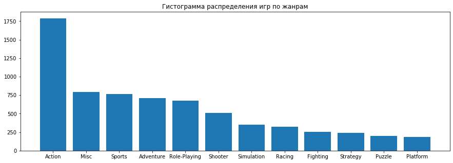

```python
plt.figure(figsize=(15, 5))
plt.bar(games2['genre'].value_counts().index, games2['genre'].value_counts())
plt.title('Гистограмма распределения игр по жанрам');
```

## Вывод

Платформы с наибольшими суммарными продажами — мёртвые платформы. Средний жизненный цикл платформы — 8.5 лет.

Самые прибыльные платформы на 2017 год — *PS4* и *Xbox One*. Продажи игр на *3DS* и *WiiU* падают. *PC* — самая стабильная платформа.

Рынок игр для всех платформ неоднороден. Есть очевидные хиты продаж и множество проходных игр.

Продажи мало зависят от отзывов пользователей и критиков.

Лучше всего продаются экшен игры, шутеры и спортивные симуляторы. Хуже всего — приключения, стратегии и пазлы.

## Шаг 4. Составьте портрет пользователя каждого региона

Определим самые популярные платформы по регионам. Для этого создадим сводную таблицу `popular_region_platforms`, сгруппировав по платформам и просуммировав продажи по каждому региону.

```python
popular_region_platforms = games2.pivot_table(index='platform', values=['na_sales', 'eu_sales', 'jp_sales'], aggfunc='sum')
popular_region_platforms
```

| platform | eu_sales | jp_sales | na_sales |
| --- | --- | --- | --- |
| 2600 | 0.07 | 0.00 | 1.10 |
| 3DS | 61.48 | 100.65 | 83.13 |
| DS | 54.18 | 52.11 | 121.61 |
| PC | 84.28 | 0.00 | 41.59 |
| PS2 | 6.61 | 2.74 | 11.68 |
| PS3 | 256.72 | 69.00 | 293.44 |
| PS4 | 141.09 | 15.96 | 108.74 |
| PSP | 18.34 | 50.88 | 22.37 |
| PSV | 13.12 | 21.91 | 12.58 |
| Wii | 124.65 | 34.34 | 238.38 |
| WiiU | 25.13 | 13.01 | 38.10 |
| X360 | 198.11 | 7.46 | 410.99 |
| XB | 0.38 | 0.00 | 0.76 |
| XOne | 51.59 | 0.34 | 93.12 |

Отсортируем сводную таблицу `popular_region_platforms` по убыванию продаж в Северной Америке и выведем на экран первые 5 штук.

```python
top5_popular_na_platforms = popular_region_platforms.sort_values(by='na_sales', ascending=False)['na_sales'].head()
top5_popular_na_platforms
```

```
platform
X360    410.99
PS3     293.44
Wii     238.38
DS      121.61
PS4     108.74
Name: na_sales, dtype: float64
```

Отсортируем сводную таблицу `popular_region_platforms` по убыванию продаж в Европе и выведем на экран первые 5 штук.

```python
top5_popular_eu_platforms = popular_region_platforms.sort_values(by='eu_sales', ascending=False)['eu_sales'].head()
top5_popular_eu_platforms
```

```
platform
PS3     256.72
X360    198.11
PS4     141.09
Wii     124.65
PC       84.28
Name: eu_sales, dtype: float64
```

Отсортируем сводную таблицу `popular_region_platforms` по убыванию продаж в Японии и выведем на экран первые 5 штук.

```python
top5_popular_jp_platforms = popular_region_platforms.sort_values(by='jp_sales', ascending=False)['jp_sales'].head()
top5_popular_jp_platforms
```

```
platform
3DS    100.65
PS3     69.00
DS      52.11
PSP     50.88
Wii     34.34
Name: jp_sales, dtype: float64
```

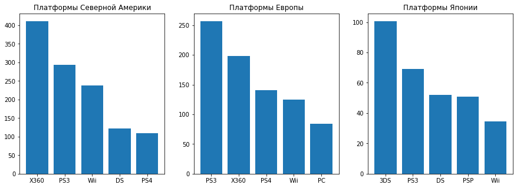

```python
plt.figure(figsize=(15, 5))
plt.subplot(1, 3, 1)
plt.bar(top5_popular_na_platforms.index, top5_popular_na_platforms)
plt.title('Платформы Северной Америки');
plt.subplot(1, 3, 2)
plt.bar(top5_popular_eu_platforms.index, top5_popular_eu_platforms)
plt.title('Платформы Европы');
plt.subplot(1, 3, 3)
plt.bar(top5_popular_jp_platforms.index, top5_popular_jp_platforms)
plt.title('Платформы Японии');
```

**Вывод:** в Северной Америке популярнее *Xbox*, в Европе — *PlayStation*, в Японии — более экзотические приставки, такие как *Nintendo*.

Определим самые популярные жанры по регионам. Для этого создадим сводную таблицу `popular_region_genres`, сгруппировав по жанрам и просуммировав продажи по каждому региону.

```python
popular_region_genres = games2.pivot_table(index='genre', values=['na_sales', 'eu_sales', 'jp_sales'], aggfunc='sum')
popular_region_genres
```

| genre | eu_sales | jp_sales | na_sales |
| --- | --- | --- | --- |
| Action | 275.51 | 84.80 | 367.06 |
| Adventure | 24.34 | 19.04 | 30.90 |
| Fighting | 27.74 | 16.92 | 56.56 |
| Misc | 86.37 | 30.33 | 165.01 |
| Platform | 49.68 | 20.65 | 74.98 |
| Puzzle | 12.04 | 5.05 | 20.74 |
| Racing | 68.39 | 7.19 | 61.63 |
| Role-Playing | 83.73 | 120.75 | 131.19 |
| Shooter | 193.65 | 15.22 | 277.80 |
| Simulation | 37.90 | 14.27 | 44.54 |
| Sports | 158.92 | 25.32 | 229.06 |
| Strategy | 17.48 | 8.86 | 18.12 |

Отсортируем сводную таблицу `popular_region_genres` по убыванию продаж в Северной Америке и выведем на экран первые 5 штук.

```python
top5_popular_na_genres = popular_region_genres.sort_values(by='na_sales', ascending=False)['na_sales'].head()
top5_popular_na_genres
```

```
genre
Action          367.06
Shooter         277.80
Sports          229.06
Misc            165.01
Role-Playing    131.19
Name: na_sales, dtype: float64
```

Отсортируем сводную таблицу `popular_region_genres` по убыванию продаж в Европе и выведем на экран первые 5 штук.

```python
top5_popular_eu_genres = popular_region_genres.sort_values(by='eu_sales', ascending=False)['eu_sales'].head()
top5_popular_eu_genres
```

```
genre
Action          275.51
Shooter         193.65
Sports          158.92
Misc             86.37
Role-Playing     83.73
Name: eu_sales, dtype: float64
```

Отсортируем сводную таблицу `popular_region_genres` по убыванию продаж в Японии и выведем на экран первые 5 штук.

```python
top5_popular_jp_genres = popular_region_genres.sort_values(by='jp_sales', ascending=False)['jp_sales'].head()
top5_popular_jp_genres
```

```
genre
Role-Playing    120.75
Action           84.80
Misc             30.33
Sports           25.32
Platform         20.65
Name: jp_sales, dtype: float64
```

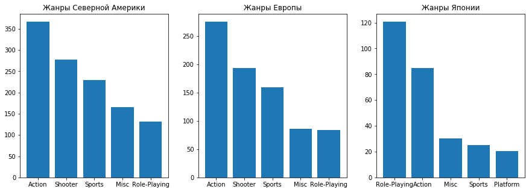

```python
plt.figure(figsize=(15, 5))
plt.subplot(1, 3, 1)
plt.bar(top5_popular_na_genres.index, top5_popular_na_genres)
plt.title('Жанры Северной Америки');
plt.subplot(1, 3, 2)
plt.bar(top5_popular_eu_genres.index, top5_popular_eu_genres)
plt.title('Жанры Европы');
plt.subplot(1, 3, 3)
plt.bar(top5_popular_jp_genres.index, top5_popular_jp_genres)
plt.title('Жанры Японии');
```

**Вывод:** жанровые предпочтения игроков из Северной Америки и Европы схожи, это — экшен игры, спортивные симуляторы и шутеры. Но в Японии популярнее всего ролевые игры.

```python
ESRB_regions = games2.pivot_table(index='rating', values=['na_sales', 'eu_sales', 'jp_sales'], aggfunc='sum')
ESRB_regions
```

| rating | eu_sales | jp_sales | na_sales |
| --- | --- | --- | --- |
| E | 261.79 | 61.49 | 405.75 |
| E10+ | 123.52 | 20.82 | 205.37 |
| EC | 0.00 | 0.00 | 1.32 |
| M | 329.57 | 36.29 | 444.13 |
| RP | 0.07 | 0.00 | 0.00 |
| T | 154.32 | 50.76 | 229.07 |

Отсортируем сводную таблицу `ESRB_regions` по убыванию продаж в Северной Америке и выведем на экран первые 5 штук.

```python
top5_ESRB_na = ESRB_regions.sort_values(by='na_sales', ascending=False)['na_sales'].head()
top5_ESRB_na
```

```
rating
M       444.13
E       405.75
T       229.07
E10+    205.37
EC        1.32
Name: na_sales, dtype: float64
```

Отсортируем сводную таблицу `ESRB_regions` по убыванию продаж в Европе и выведем на экран первые 5 штук.

```python
top5_ESRB_eu = ESRB_regions.sort_values(by='eu_sales', ascending=False)['eu_sales'].head()
top5_ESRB_eu
```

```
rating
M       329.57
E       261.79
T       154.32
E10+    123.52
RP        0.07
Name: eu_sales, dtype: float64
```

Отсортируем сводную таблицу `ESRB_regions` по убыванию продаж в Японии и выведем на экран первые 5 штук.

```python
top5_ESRB_jp = ESRB_regions.sort_values(by='jp_sales', ascending=False)['jp_sales'].head()
top5_ESRB_jp
```

```
rating
E       61.49
T       50.76
M       36.29
E10+    20.82
EC       0.00
Name: jp_sales, dtype: float64
```

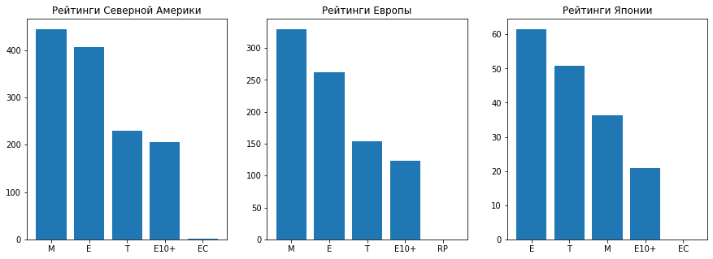

```python
plt.figure(figsize=(15, 5))
plt.subplot(1, 3, 1)
plt.bar(top5_ESRB_na.index, top5_ESRB_na)
plt.title('Рейтинги Северной Америки');
plt.subplot(1, 3, 2)
plt.bar(top5_ESRB_eu.index, top5_ESRB_eu)
plt.title('Рейтинги Европы');
plt.subplot(1, 3, 3)
plt.bar(top5_ESRB_jp.index, top5_ESRB_jp)
plt.title('Рейтинги Японии');
```

**Вывод:** в Европе и Северной Америке популярны жанры «Mature» — «Для взрослых» и «Everyone» — «Для всех». В Японии предпочитают «Everyone» — «Для всех» и «Teen» — «Для подростков».

## Вывод

В Северной Америке популярнее *Xbox*, в Европе — *PlayStation*, в Японии — более экзотические приставки, такие как *Nintendo*.

Жанровые предпочтения игроков из Северной Америки и Европы схожи, это — экшен игры, спортивные симуляторы и шутеры. Но в Японии популярнее всего ролевые игры.

В Европе и Северной Америке популярны жанры «Mature» — «Для взрослых» и «Everyone» — «Для всех». В Японии предпочитают «Everyone» — «Для всех» и «Teen» — «Для подростков».

## Шаг 5. Проверьте гипотезы

Сформулируем следующие гипотезы.

Нулевая гипотеза: средние пользовательские рейтинги платформ *Xbox One* и *PC* одинаковые.

Альтернативная гипотеза: средние пользовательские рейтинги платформ *Xbox One* и *PC* различаются.

Выборки независимы, поскольку мы измеряем рейтинги двух разных игровых платформ.

Выберем пользовательские рейтинги на платформе *Xbox One* методом `query()`, удалив пустые значения методом `dropna()`.

```python
XOne_user_scores = games2.query('platform == "XOne"')['user_score'].dropna()
XOne_user_scores
```

```
99       8.1
165      7.9
179      5.4
242      6.4
270      6.2
        ...
16630    8.2
16643    6.6
16645    7.2
16660    6.7
16672    9.5
Name: user_score, Length: 246, dtype: float64
```

Выберем пользовательские рейтинги на платформе *PC* методом `query()`, удалив пустые значения методом `dropna()`.

```python
PC_user_scores = games2.query('platform == "PC"')['user_score'].dropna()
PC_user_scores
```

```
85       7.6
192      4.0
218      8.2
313      8.1
458      3.9
        ...
16690    6.7
16692    7.6
16696    5.8
16702    7.2
16705    5.8
Name: user_score, Length: 583, dtype: float64
```

Найдём дисперсии пользовательских рейтингов платформ *Xbox One* и *PC* соответственно.

```python
np.var(XOne_user_scores)
```

```
1.8590752858748099
```

```python
np.var(PC_user_scores)
```

```
2.275273221551742
```

Проверим гипотезу о равенстве среднего двух генеральных совокупностей методом `scipy.stats.ttest_ind()`. Дисперсии пользовательских рейтингов платформ *Xbox One* и *PC* различаются, поэтому примем параметр equal_var = False.

```python
alpha = 0.05 # пороговое значение

results = st.ttest_ind(
    XOne_user_scores,
    PC_user_scores,
    equal_var = False
)

print('p-значение:', results.pvalue)

if (results.pvalue < alpha):
    print("Отвергаем нулевую гипотезу")
else:
    print("Не получилось отвергнуть нулевую гипотезу")
```

```
p-значение: 0.5742999617022789
Не получилось отвергнуть нулевую гипотезу
```

Сформулируем следующие гипотезы.

Нулевая гипотеза: средние пользовательские рейтинги жанров *Action* и *Sports* одинаковые.

Альтернативная гипотеза: средние пользовательские рейтинги жанров *Action* и *Sports* разные.

Выборки независимы, поскольку мы измеряем рейтинги двух разных жанров.

Выберем пользовательские рейтинги жанров *Action* методом `query()`, удалив пустые значения методом `dropna()`.

```python
action_user_scores = games2.query('genre == "Action"')['user_score'].dropna()
action_user_scores
```

```
16       8.2
23       8.1
42       8.3
46       8.7
81       6.6
        ...
16680    7.2
16691    5.7
16692    7.6
16699    6.7
16710    7.4
Name: user_score, Length: 1660, dtype: float64
```

Выберем пользовательские рейтинги жанров *Sports* методом `query()`, удалив пустые значения методом `dropna()`.

```python
sports_user_scores = games2.query('genre == "Sports"')['user_score'].dropna()
sports_user_scores
```

```
3        8.0
15       7.4
77       4.3
94       5.0
119      4.2
        ...
16638    5.3
16639    7.1
16643    6.6
16688    4.8
16700    6.0
Name: user_score, Length: 716, dtype: float64
```

Найдём дисперсии пользовательских рейтингов жанров *Action* и *Sports* соответственно.

```python
np.var(action_user_scores)
```

```
1.9941436928436638
```

```python
np.var(sports_user_scores)
```

```
2.717323956025093
```

Проверим гипотезу о равенстве среднего двух генеральных совокупностей методом `scipy.stats.ttest_ind()`. Дисперсии пользовательских рейтингов жанров *Action* и *Sports* различаются, поэтому примем параметр equal_var = False.

```python
alpha = 0.05 # пороговое значение

results = st.ttest_ind(
    action_user_scores,
    sports_user_scores,
    equal_var = False
)

print('p-значение:', results.pvalue)

if (results.pvalue < alpha):
    print("Отвергаем нулевую гипотезу")
else:
    print("Не получилось отвергнуть нулевую гипотезу")
```

```
p-значение: 4.432399268923206e-12
Отвергаем нулевую гипотезу
```

**Вывод:** средние пользовательские рейтинги жанров *Action* и *Sports* разные.

## Вывод

Средние пользовательские рейтинги жанров *Action* и *Sports* разные.

## Шаг 6. Напишите общий вывод

Для заполнения пропусков в столбцах можно копировать значения из открытых источников средством автоматизации AutoIt.

Возможные причины пропусков — ошибки названий для серий игр или для малоизвестность тайтлов.

Пропуски в столбцах *critic_score*, *rating* оставим без изменения, поскольку удаление соответствующих строк может негативно сказаться на результатах исследования.

Аббревиатура tbd (To Be Determined — будет определено или To Be Decided — будет решено) в столбцах с оценками пользователей означает, что пользовательские оценки отсутствуют или их недостаточно, чтобы выставить оценку игре.

Платформы с наибольшими суммарными продажами — мёртвые платформы. Средний жизненный цикл платформы — 8.5 лет.

Самые прибыльные платформы на 2017 год — *PS4* и *Xbox One*. Продажи игр на *3DS* и *WiiU* падают. *PC* — самая стабильная платформа.

Рынок игр для всех платформ неоднороден. Есть очевидные хиты продаж и множество проходных игр.

Продажи мало зависят от отзывов пользователей и критиков.

Лучше всего продаются экшен игры, шутеры и спортивные симуляторы. Хуже всего — приключения, стратегии и пазлы.

В Северной Америке популярнее *Xbox*, в Европе — *PlayStation*, в Японии — более экзотические приставки, такие как *Nintendo*.

Жанровые предпочтения игроков из Северной Америки и Европы схожи, это — экшен игры, спортивные симуляторы и шутеры. Но в Японии популярнее всего ролевые игры.

В Европе и Северной Америке популярны жанры «Mature» — «Для взрослых» и «Everyone» — «Для всех». В Японии предпочитают «Everyone» — «Для всех» и «Teen» — «Для подростков».

Средние пользовательские рейтинги жанров *Action* и *Sports* разные.